# Tutoriel Python

Ce tutoriel a pour but de guider les personnes souhaitant utiliser Python pour participer au challenge.

Il comporte cinq etapes :

- Import des donnees
- Analyse descriptive
- Preparation des donnees
- Creation d’un modele en cross validation
- Calcul des predictions et soumission

# Import des données

Avant de rentrer dans le vif du sujet, importons quelques packages necessaires pour ce tutoriel :

```python
import pandas as pd
import numpy as np
from sklearn.preprocessing import LabelEncoder
from sklearn.cross_validation import KFold
from sklearn.ensemble import RandomForestRegressor
import matplotlib.pyplot as plt
%matplotlib inline
```

```python
# Librairie de visualisation super cool
import seaborn as sns # pip install seaborn
```

Les datasets sont sous format .csv. Vous pouvez les importer avec le code ci-dessous.

```python
train = pd.read_csv('../data_challenge/boites_medicaments_train.csv',
                    encoding='utf-8',
                    sep=';')

test = pd.read_csv('../data_challenge/boites_medicaments_test.csv',
                   encoding='utf-8',
                   sep=';')
```

```python
pd.set_option("display.max_columns", 99) # permet de voir toutes les colonnes
train.head(10)
```

|  | libelle | libelle_plaquette | libelle_ampoule | libelle_flacon | libelle_tube | libelle_stylo | libelle_seringue | libelle_pilulier | libelle_sachet | libelle_comprime | libelle_gelule | libelle_film | libelle_poche | libelle_capsule | nb_plaquette | nb_ampoule | nb_flacon | nb_tube | nb_stylo | nb_seringue | nb_pilulier | nb_sachet | nb_comprime | nb_gelule | nb_film | nb_poche | nb_capsule | nb_ml | statut | … |
| --- | --- | --- | --- | --- | --- | --- | --- | --- | --- | --- | --- | --- | --- | --- | --- | --- | --- | --- | --- | --- | --- | --- | --- | --- | --- | --- | --- | --- | --- | --- |
| 0 | 3 plaquette(s) thermoformée(s) PVC-Aluminium d... | 1 | 0 | 0 | 0 | 0 | 0 | 0 | 0 | 1 | 0 | 0 | 0 | 0 | 3 | 0 | 0 | 0 | 0 | 0 | 0 | 0 | 28 | 0 | 0 | 0 | 0 | 0 | Présentation active | … |
| 1 | plaquette(s) thermoformée(s) aluminium de 28 c... | 1 | 0 | 0 | 0 | 0 | 0 | 0 | 0 | 1 | 0 | 0 | 0 | 0 | 0 | 0 | 0 | 0 | 0 | 0 | 0 | 0 | 28 | 0 | 0 | 0 | 0 | 0 | Présentation active | … |
| 2 | plaquette(s) thermoformée(s) PVC-aluminium de ... | 1 | 0 | 0 | 0 | 0 | 0 | 0 | 0 | 0 | 1 | 0 | 0 | 0 | 0 | 0 | 0 | 0 | 0 | 0 | 0 | 0 | 0 | 30 | 0 | 0 | 0 | 0 | Présentation active | … |
| 3 | 30 sachet(s)-dose(s) papier aluminium complexe... | 0 | 0 | 0 | 0 | 0 | 0 | 0 | 1 | 0 | 0 | 0 | 0 | 0 | 0 | 0 | 0 | 0 | 0 | 0 | 0 | 30 | 0 | 0 | 0 | 0 | 0 | 0 | Présentation active | … |
| 4 | plaquette(s) thermoformée(s) PVC-Aluminium de ... | 1 | 0 | 0 | 0 | 0 | 0 | 0 | 0 | 1 | 0 | 0 | 0 | 0 | 0 | 0 | 0 | 0 | 0 | 0 | 0 | 0 | 30 | 0 | 0 | 0 | 0 | 0 | Présentation active | … |
| 5 | plaquette(s) thermoformée(s) PVC-aluminium de ... | 1 | 0 | 0 | 0 | 0 | 0 | 0 | 0 | 1 | 0 | 0 | 0 | 0 | 0 | 0 | 0 | 0 | 0 | 0 | 0 | 0 | 30 | 0 | 0 | 0 | 0 | 0 | Présentation active | … |
| 6 | flacon(s) polyéthylène haute densité (PEHD) de... | 0 | 0 | 1 | 0 | 0 | 0 | 0 | 0 | 0 | 0 | 0 | 0 | 1 | 0 | 0 | 0 | 0 | 0 | 0 | 0 | 0 | 0 | 0 | 0 | 0 | 100 | 0 | Présentation active | … |
| 7 | plaquette(s) thermoformée(s) PVC polyéthylène ... | 1 | 0 | 0 | 0 | 0 | 0 | 0 | 0 | 1 | 0 | 0 | 0 | 0 | 0 | 0 | 0 | 0 | 0 | 0 | 0 | 0 | 30 | 0 | 0 | 0 | 0 | 0 | Présentation active | … |
| 8 | plaquette(s) thermoformée(s) PVC-Aluminium de ... | 1 | 0 | 0 | 0 | 0 | 0 | 0 | 0 | 1 | 0 | 0 | 0 | 0 | 0 | 0 | 0 | 0 | 0 | 0 | 0 | 0 | 90 | 0 | 0 | 0 | 0 | 0 | Présentation active | … |
| 9 | plaquette(s) polyamide aluminium PVC de 10 com... | 1 | 0 | 0 | 0 | 0 | 0 | 0 | 0 | 1 | 0 | 0 | 0 | 0 | 0 | 0 | 0 | 0 | 0 | 0 | 0 | 0 | 10 | 0 | 0 | 0 | 0 | 0 | Présentation active | … |

On est maintenant pret a attaquer les choses serieuses ! :)

# Analyse descriptive

### Structure des datasets

Le dataset `train` comporte les caracteristiques et prix de 8564 boites de medicaments. C'est ce dataset que nous allons utiliser pour creer un modele. Chaque boite de medicament est decrite par une observation de 41 variables. Ces variables sont decrites dans le fichier `Description.pdf` present dans la cle usb.

Le dataset `test` comporte les caracteristiques des 3671 boites de medicaments dont il faut predire le prix. A la difference de `train`, le prix des boites de medicaments n'est bien sur pas inclus et une colonne `id` a ete ajoutée pour identifier les boites de medicaments pendant l'etape de soumission des predictions sur Datascience.net

### Distribution des donnees

Jetons maintenant un coup d'oeil a la distribution des donnees

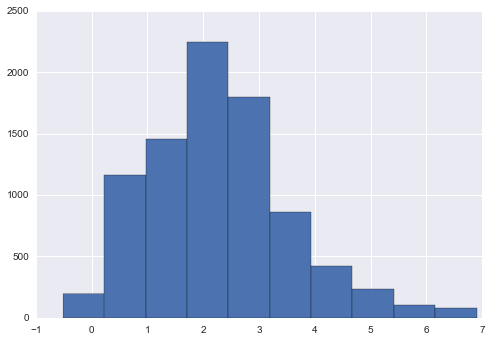

```python
# Distribution du log des prix
# On prend le log des prix car sa distribution est plus proche d'une gaussienne
train['logprix'] = train['prix'].apply(np.log)
train['logprix'].hist()
```

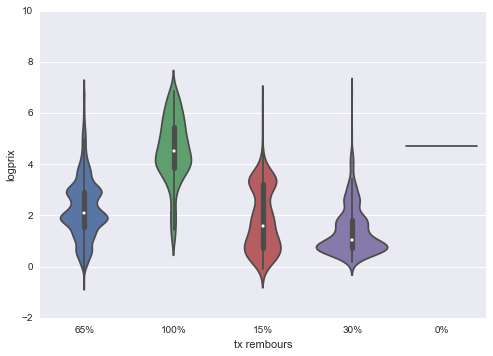

```python
# Influence sur les prix de la feature "tx rembours"
sns.violinplot(y="logprix", x="tx rembours", data=train)
```

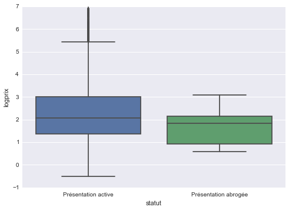

```python
# Influence sur les prix de la feature "statut"
sns.boxplot(y="logprix", x="statut", data=train)
```

# Preparation des donnees

### Types de features

```python
# features numériques
feat_num = ['libelle_plaquette', 'libelle_ampoule', 'libelle_flacon',
            'libelle_tube', 'libelle_stylo', 'libelle_seringue',
            'libelle_pilulier', 'libelle_sachet', 'libelle_comprime',
            'libelle_gelule', 'libelle_film', 'libelle_poche',
            'libelle_capsule'] + ['nb_plaquette', 'nb_ampoule',
            'nb_flacon', 'nb_tube', 'nb_stylo', 'nb_seringue',
            'nb_pilulier', 'nb_sachet', 'nb_comprime', 'nb_gelule',
            'nb_film', 'nb_poche', 'nb_capsule', 'nb_ml']
# features date
feat_dates = ['date declar annee', 'date amm annee']
# features catégorielles
feat_cat = ['statut', 'etat commerc', 'agrement col', 'tx rembours',
          'voies admin', 'statut admin', 'type proc']
# features texte
feat_text = ['libelle', 'titulaires', 'substances', 'forme pharma']
```

### Encodage des features catégorielles

Les algorithmes de machine learning s'attendent à avoir en entrée des nombres, et non pas des chaînes de caractères. C'est pourquoi nous transformons les features catégorielles en nombres, à l'aide de LabelEncoder()

```python
for c in feat_cat:
    le = LabelEncoder()
    le.fit(train[c].append(test[c]))
    train[c] = le.transform(train[c])
    test[c] = le.transform(test[c])
```

# Creation d'un modele

Il est maintenant temps de creer un modele. Dans ce tutoriel nous allons construire une [Foret Aleatoire](https://fr.wikipedia.org/wiki/For%C3%AAt_d'arbres_d%C3%A9cisionnels)

Pour eviter le [surapprentissage](https://fr.wikipedia.org/wiki/Surapprentissage) et estimer les vraies performances de notre modele nous allons utiliser le critère de [validation croisee](https://fr.wikipedia.org/wiki/Validation_crois%C3%A9e) (cross-validation) methode k-fold.

### Métrique MAPE

La métrique MAPE n'étant pas disponible dans scikit-learn, nous la codons

```python
# Mean Absolute Percentage Error
def mape_error(y_true, y_pred):
    return np.mean(np.abs((y_true - y_pred) / y_true)) * 100
```

### Cross validation

```python
err = 0
NBROUND = 5
FEATURES = feat_num+feat_cat # on n'utilise que ces features pour ce modèle basique
for train_index, test_index in KFold(train.shape[0], n_folds=NBROUND):
    y = train['logprix']
    X = train[FEATURES]
    X_train, X_test = X.ix[train_index, :], X.ix[test_index, :]
    y_train, y_test = y[train_index], y[test_index]
    clf = RandomForestRegressor()
    clf.fit(X_train, y_train)
    pred = clf.predict(X_test)
    # ne pas oublier de reprendre l'exponentielle de la prédiction
    err += mape_error(np.exp(y_test), np.exp(pred))
    print mape_error(np.exp(y_test), np.exp(pred))
print "*** MAPE Error : ", err / NBROUND
```

```
67.2682288617
70.1046218092
65.9190239145
63.8031402385
59.4904694429
*** MAPE Error :  65.3170968534
```

Cela veut dire notre modele predit les prix des medicaments avec environ 65% d’erreur en moyenne. Par exemple, si un medicament vaut reellement 10€, notre prediction sera de 16.5€ (ou 3.5€).

# Calcul des predictions et soumission

```python
clf = RandomForestRegressor()
# On entraine de nouveau le modèle, cette fois sur l'intégralité des données
clf.fit(train[FEATURES], train['logprix'])
predictions = np.exp(clf.predict(test[FEATURES]))
```

```python
pd.DataFrame(predictions, index=test['id']).to_csv('soumission.csv',
                          header=['prix'],
                          sep = ';')
```

Vous etes maintenant pret ? Faites votre premiere soumission en uplodant le fichier `soumission.csv` sur Datascience.net